# IODS course project

Ella

# About the project

This course has been very difficult, but hopefully I got it right!

(https://github.com/ellavain/IODS-project)

# 2. Regression and model validation, analysis

*Describe the work you have done this week and summarize your learning.*

*- Describe your work and results clearly.* *- Assume the reader has an introductory course level understanding of writing and reading R code as well as statistical methods* *- Assume the reader has no previous knowledge of your data or the more advanced methods you are using*

## Summary of the data

```r
data1 <- read.table("data/learning2014.txt" , sep = ",",
header = TRUE)
```

This weeks tasks is to present the material we are going to be working with and run a multiple regression model. While presenting the material, we will also need to provide visuals of the multiple regression models and the distribution of each variable. We have to explain the outputs of visuals and summaries.

I begin to visualize the content of the whole material, so I summarise the content of the variable data1, and then I will proceed to visualize data1’s different dimensions:

```r
summary(data1)
```

```
##  gender       age           attitude          deep            stra
##  F:110   Min.   :17.00   Min.   :1.400   Min.   :1.583   Min.   :1.250
##  M: 56   1st Qu.:21.00   1st Qu.:2.600   1st Qu.:3.333   1st Qu.:2.625
##          Median :22.00   Median :3.200   Median :3.667   Median :3.188
##          Mean   :25.51   Mean   :3.143   Mean   :3.680   Mean   :3.121
##          3rd Qu.:27.00   3rd Qu.:3.700   3rd Qu.:4.083   3rd Qu.:3.625
##          Max.   :55.00   Max.   :5.000   Max.   :4.917   Max.   :5.000
##       surf           points
##  Min.   :1.583   Min.   : 7.00
##  1st Qu.:2.417   1st Qu.:19.00
##  Median :2.833   Median :23.00
##  Mean   :2.787   Mean   :22.72
##  3rd Qu.:3.167   3rd Qu.:27.75
##  Max.   :4.333   Max.   :33.00
```

```r
dim(data1)
```

```
## [1] 166   7
```

As we can se, the data consists of 7 different variables gender, age, attitude, deep, stra, surf and points, and it has a total of 166 observations. The summary function gives 6 different basic key figures; minimum, 1st quartile, median, mean, 3rd quartile and maximum values.

The minimum and maximum values gives the variables smallest and largest values.

The 1st and the 3rd quartile explain how many people are in the first 25% of the content (1st), and how many are included in the first 75%. These functions are usefull, because you will know where the middle 50% of the content has placed themselves.

Median is the value that is in the middle, if you gather the data in the order that the smallest values comes first, and the highest values comes last.

The mean value is the all the values of a variable divided in the numbers of observatios there is int the variable.

Now I want to present the structure of the data, which includes what type of variables (numerical, logical, character).

```r
str(data1)
```

```
## 'data.frame':    166 obs. of  7 variables:
##  $ gender  : Factor w/ 2 levels "F","M": 1 2 1 2 2 1 2 1 2 1 ...
##  $ age     : int  53 55 49 53 49 38 50 37 37 42 ...
##  $ attitude: num  3.7 3.1 2.5 3.5 3.7 3.8 3.5 2.9 3.8 2.1 ...
##  $ deep    : num  3.58 2.92 3.5 3.5 3.67 ...
##  $ stra    : num  3.38 2.75 3.62 3.12 3.62 ...
##  $ surf    : num  2.58 3.17 2.25 2.25 2.83 ...
##  $ points  : int  25 12 24 10 22 21 21 31 24 26 ...
```

We can see how the different variables are coded either with ‘num’,‘int’ or ‘Factor’. This provides information on how the variables has been measured.

The code ‘int’ means intervall, and these variables can range between a surtain amount of i.e. points. Intervall data has the same range between every outcome, i.e. the variable age is easy to measure and compare, because for every year, there is the same distance.

## Visualizing variable distributions

### -gender variable

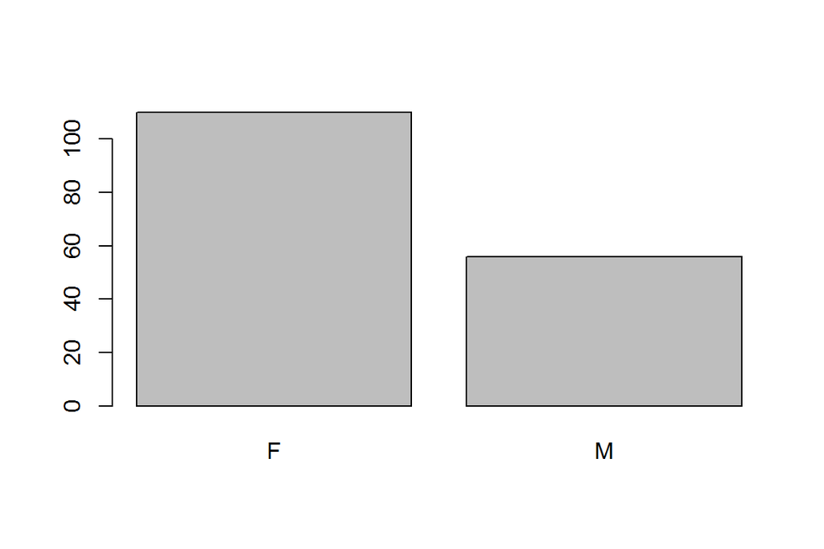

```r
plot(data1$gender)
```

As we can se, a majority of the respondents are women, and from the summary we can find that there are 110 women and 56 men.

### -age variable

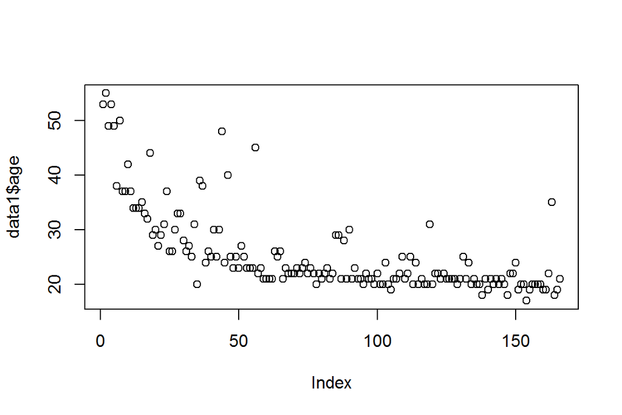

```r
plot(data1$age)
```

Here we can see that most of the respondents are in their 20s (between 21 and 27) and the mean age is arounf 25.5 years. 75% av the respodents are 27 or below, so we have quite young respondents.

### -Attitude variable

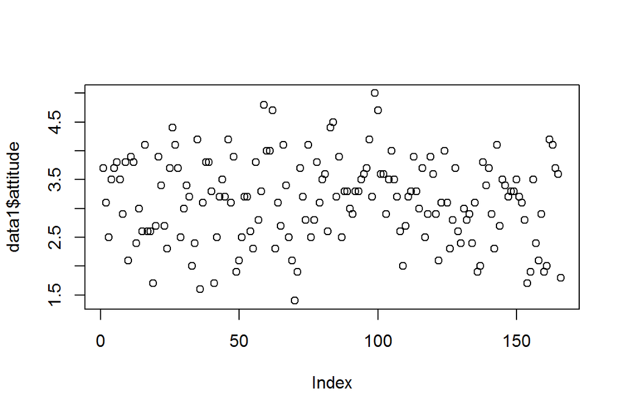

```r
plot(data1$attitude)
```

Here we can se how the the attitude variable is very scattered, and has a median and mean around 3. The variable ranges from 1 to 5. This could indicate that people have very different attitudes regarding this surtain topic.

### -Deep variable

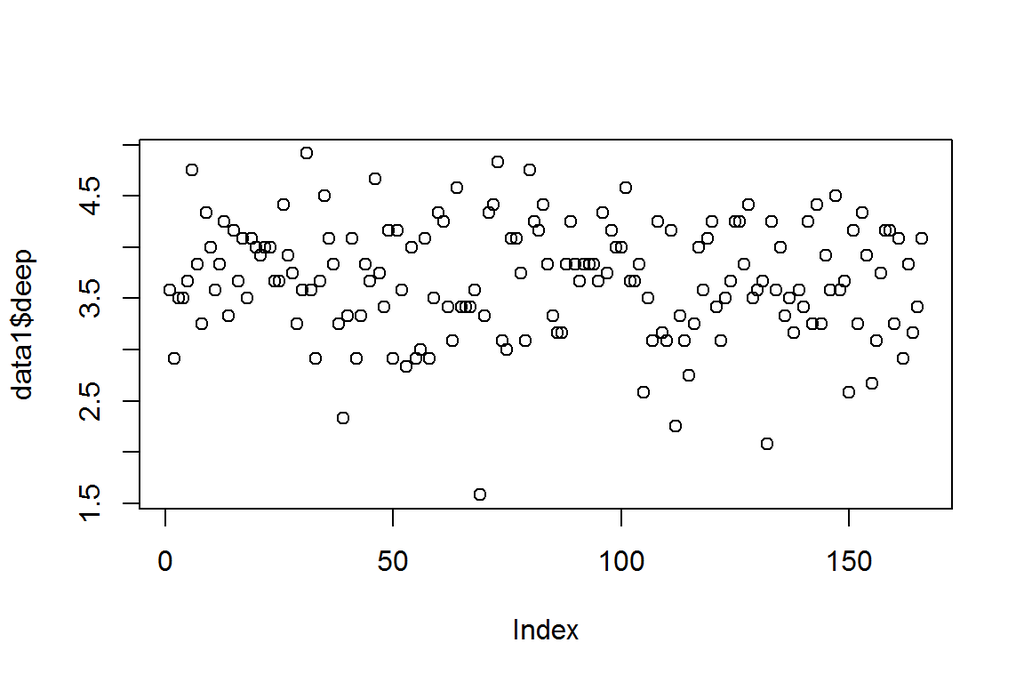

```r
plot(data1$deep)
```

Here we can se that most of the respondents has a value between 3 and 4 (1st and 3d quartile) on the deep variable.

### - Stra variable

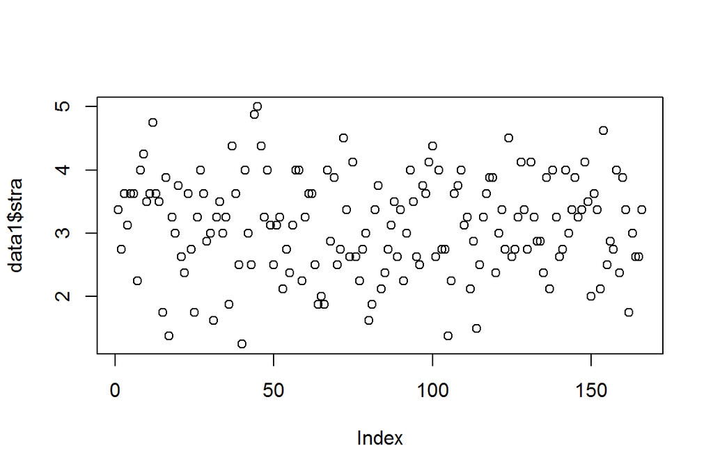

```r
plot(data1$stra)
```

The distribution in variable stra is also quite scattered, but the middle 50% is between 2,625 and 3,625 (1st and 3rd quartile).

### - Surf variable

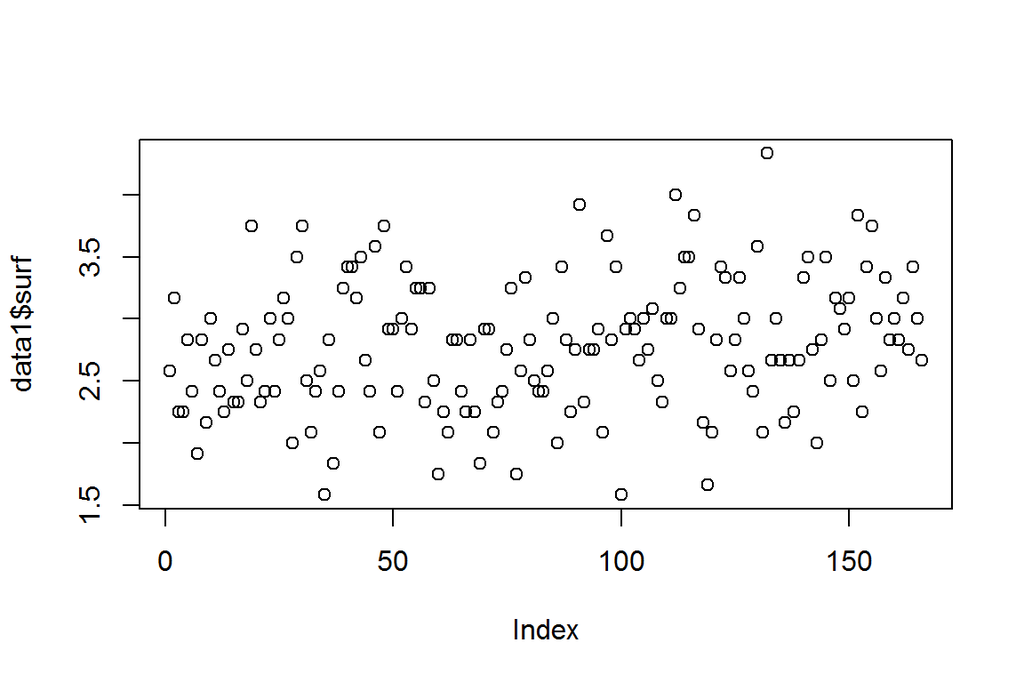

```r
plot(data1$surf)
```

In the surf variable we can see that the distribution is gathered between 2,4 and 3,4. But over all this variable is also quite scattered.

### -points variable

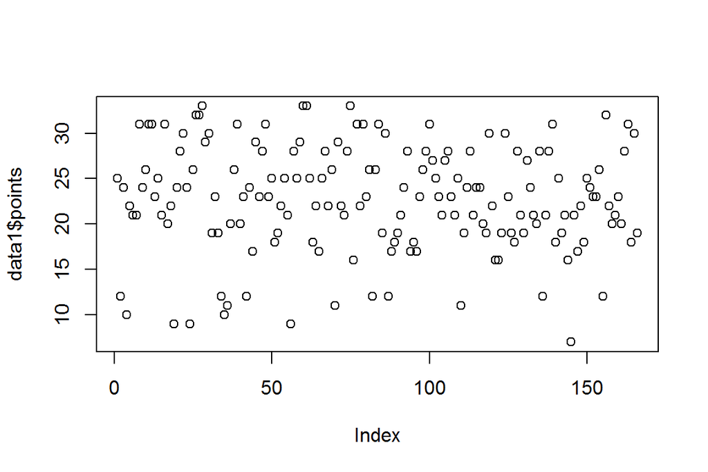

```r
plot(data1$points)
```

Here we can se that the points range between 7 and 33 points, and most of the respondents has over 20 points.

### All variables compared with each other

Now when I have all the summaries of the variables, I want to present a table where all the variables are compared with each other. The color distribution separates between women and men.

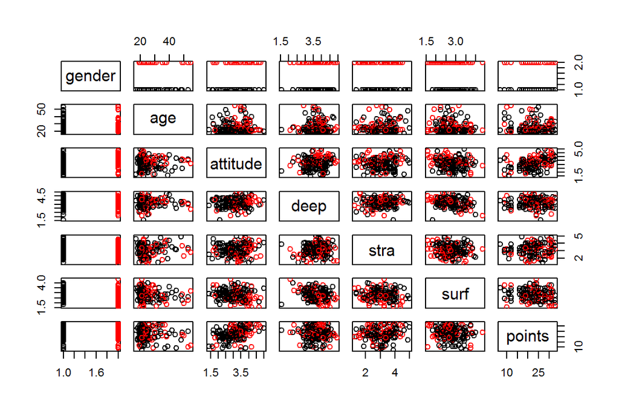

```r
pairs(data1, col = data1$gender)
```

From this table you can see if any of the different variabes correlate with each other to some extent. This is a good table to visualize the whole materials distribution in one picture.

### -Task 3, multiple regression

I created a function consisting of a multiple regression. The target variable is points, and the 3 explanatory variables are attitude, stra and deep.

```r
model1 <- lm(data1$points ~ data1$attitude + data1$stra + data1$deep, data = data1)
```

And now a summary of the multiple regression model:

```r
summary(model1)
```

```
##
## Call:
## lm(formula = data1$points ~ data1$attitude + data1$stra + data1$deep,
##     data = data1)
##
## Residuals:
##      Min       1Q   Median       3Q      Max
## -17.5239  -3.4276   0.5474   3.8220  11.5112
##
## Coefficients:
##                Estimate Std. Error t value Pr(>|t|)
## (Intercept)     11.3915     3.4077   3.343  0.00103 **
## data1$attitude   3.5254     0.5683   6.203 4.44e-09 ***
## data1$stra       0.9621     0.5367   1.793  0.07489 .
## data1$deep      -0.7492     0.7507  -0.998  0.31974
## ---
## Signif. codes:  0 '***' 0.001 '**' 0.01 '*' 0.05 '.' 0.1 ' ' 1
##
## Residual standard error: 5.289 on 162 degrees of freedom
## Multiple R-squared:  0.2097, Adjusted R-squared:  0.195
## F-statistic: 14.33 on 3 and 162 DF,  p-value: 2.521e-08
```

Here we can see the 3 different explanatory variables, and also the target variable under the title ‘Coefficients’. The Intercept, is the value in the multiple regression where it crosses the y-axis, so it means that when all the explanatory variables (x) are 0, the regression line starts at 11.3915 on the y-axis.

The first explanatory variable attitude’s estimate is 3,5254, which means that every one point higher on the explanatory variable attitude, the target variable points will increase on average by 3,5254 points, if the other explanatory variables are constant. The second explanatory variable stra’s estimate is 0,9621, which means that every point higher on this explanatory variable, the target variable will increase on average by 0,9621 if the other explanatory variables are constant. The third explanatory variable deep’s estimate is -0,7493, which means that every one point higher on the explanatory variable deep, the target variable will on average decrease by 0,7492 points, if the other explanatory variables are constant.

But before we can accept this multiple regression model, we have to look at the Pr(>|t|). The Pr(>|t|) explain if the specific explanatory variable is statistically significant or not. Usually the boarder for being statistically significant is either 0,05 or 0,01 depending on what has been chosen. We don’t need to look at the intercepts Pr(>|t|), but we need to look at the explanatory variables Pr(>|t|). The explanatory variable attitude has a Pr(>|t|) that is smaller than 0,000, which concludes that it is statistically significant. The next explanatory variable stra has a Pr(>|t|) of 0,074, which means it is statistically insignificant, that means this variable isn’t for surtain a good model for this multiple regression. The last explanatory variable deep has aPr(>|t|) of 0,319, which means it is statistically very insignificant. Having 2 insignificant values, I will skip the value that was less significant (deep) and run the multiple regression again, but now with only 2 explanatory variables.

### -Multiple regression vol 2

```r
model2 <-(lm(data1$points ~ data1$attitude + data1$stra))
```

summary of the new model

```r
summary(model2)
```

```
##
## Call:
## lm(formula = data1$points ~ data1$attitude + data1$stra)
##
## Residuals:
##      Min       1Q   Median       3Q      Max
## -17.6436  -3.3113   0.5575   3.7928  10.9295
##
## Coefficients:
##                Estimate Std. Error t value Pr(>|t|)
## (Intercept)      8.9729     2.3959   3.745  0.00025 ***
## data1$attitude   3.4658     0.5652   6.132 6.31e-09 ***
## data1$stra       0.9137     0.5345   1.709  0.08927 .
## ---
## Signif. codes:  0 '***' 0.001 '**' 0.01 '*' 0.05 '.' 0.1 ' ' 1
##
## Residual standard error: 5.289 on 163 degrees of freedom
## Multiple R-squared:  0.2048, Adjusted R-squared:  0.1951
## F-statistic: 20.99 on 2 and 163 DF,  p-value: 7.734e-09
```

### -Multiple R Squared

The multiple R squared is how much the explanatory variables explain about the variation in the target variable.

In my secound multiple regression model the multiple R squared value is 0,2048. This value explains that 20,48% of the variation in the target value points, is explained by the variation in the explanatory variables attitude and stra.

If the explanatory variable can explain over 20% of the variation in the target variable, it is quite a good regression model.

But in my case, the secound explanatory variable was insignificant, so I am not surtain if this model is so good after all.

### -Task 5

I will produce diagnstic plots: Residuals vs Fitted values, Normal QQ-plot and Residuals vs Leverage. I will produce these plots with the multiple regression model with only 2 explanatory variables (attitude and stra).

### Residuals vs Fitted

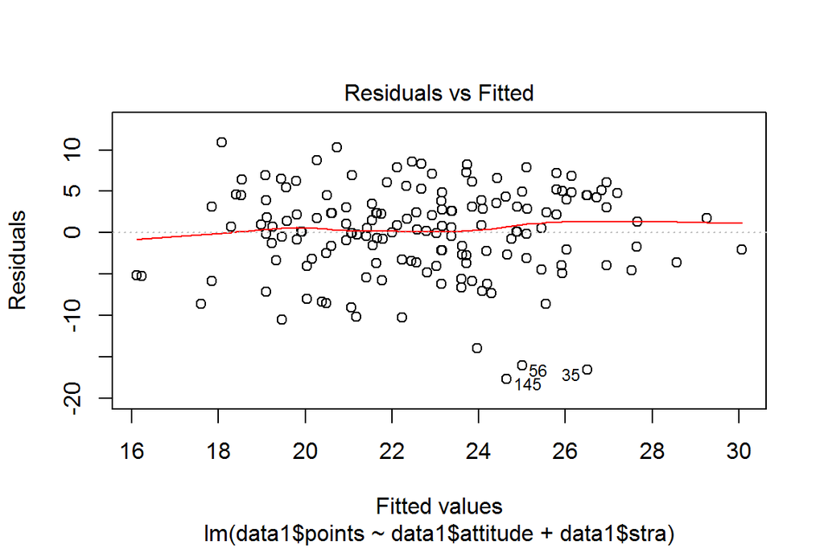

```r
plot(model2, which = c(1))
```

This table has the residual on the y-axis, and all the fitted values on the x-axis. The red stripe defines the fitted values residual and how well the multiple regressions fits this residual. We can se how most of the values are gathered between 18 to 27, and that they differ from the residuals between -10 to 10.

### Normal QQ-plot

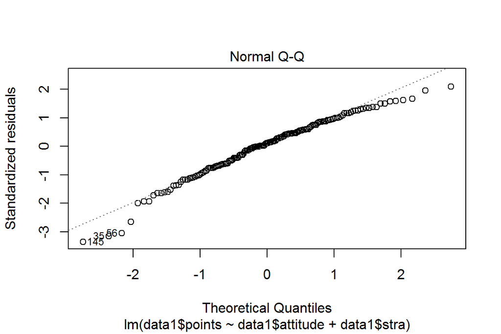

```r
plot(model2, which = c(2))
```

Here is the same thing, the better the theoretical quantiles fit on the line, the better the multiple regression is. Because the closer you are to the regression line, the better is your regression, because the closer to the residuals you are, the less error there is in you model.

### Residuals vs Leverage

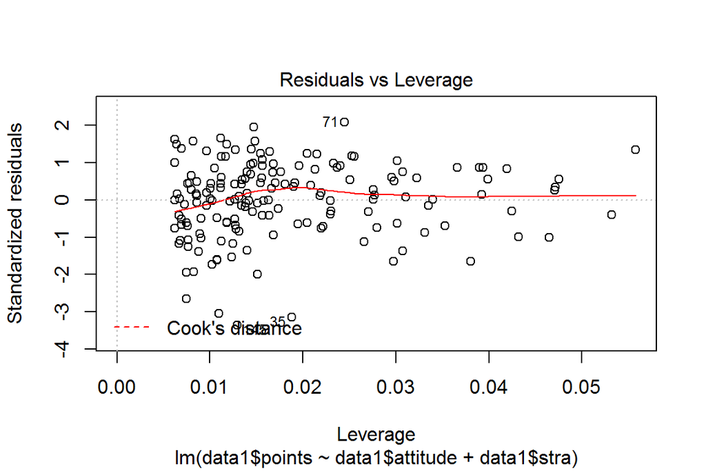

```r
plot(model2, which = c(5))
```

Here we can see how the standardized residuals are on the y-axis, and the leverage is on the x-axis. The residual axis shows how much the observations differs from the multiple regression line. The leverage on the x-axis explains how far the explanatory variables are from other observations.

### Summary of my learning

I have understood a little bit more on how to use RStudio and to syncronize with Github and so forth.

I have learned through the Datacamp excersizes new codes, that has been very usefull in this task. I have also learned to add pictures to a rmd file. I have also learned how to combine questions into new variables. But I was unable to exclude the variables that where 0 in the data wrangling excersize, so I had to use the ready made data.

I also have a slightly better understanding of the model where every variable is compared with each other. But I am quite familiar with the summary of the multiple regression model, so there was nothing very new.

```r
library(tidyr); library(dplyr); library(ggplot2); library(boot)
```

# 3. Logistic Regression

### Task 2. Brief summary of the data

Here I will present the new data, that consists of background information about the student and some personal questions regarding their life as a whole. But the variables I will be focusing on mostly in this task is ‘alc_use’ and ‘high_use’. But firstly I shall present all the variables:

```r
url <- read.table("http://s3.amazonaws.com/assets.datacamp.com/production/course_2218/datasets/alc.txt", sep=",", header=TRUE)
```

```r
str(url)
```

```
## 'data.frame':    382 obs. of  35 variables:
##  $ school    : Factor w/ 2 levels "GP","MS": 1 1 1 1 1 1 1 1 1 1 ...
##  $ sex       : Factor w/ 2 levels "F","M": 1 1 1 1 1 2 2 1 2 2 ...
##  $ age       : int  18 17 15 15 16 16 16 17 15 15 ...
##  $ address   : Factor w/ 2 levels "R","U": 2 2 2 2 2 2 2 2 2 2 ...
##  $ famsize   : Factor w/ 2 levels "GT3","LE3": 1 1 2 1 1 2 2 1 2 1 ...
##  $ Pstatus   : Factor w/ 2 levels "A","T": 1 2 2 2 2 2 2 1 1 2 ...
##  $ Medu      : int  4 1 1 4 3 4 2 4 3 3 ...
##  $ Fedu      : int  4 1 1 2 3 3 2 4 2 4 ...
##  $ Mjob      : Factor w/ 5 levels "at_home","health",..: 1 1 1 2 3 4 3 3 4 3 ...
##  $ Fjob      : Factor w/ 5 levels "at_home","health",..: 5 3 3 4 3 3 3 5 3 3 ...
##  $ reason    : Factor w/ 4 levels "course","home",..: 1 1 3 2 2 4 2 2 2 2 ...
##  $ nursery   : Factor w/ 2 levels "no","yes": 2 1 2 2 2 2 2 2 2 2 ...
##  $ internet  : Factor w/ 2 levels "no","yes": 1 2 2 2 1 2 2 1 2 2 ...
##  $ guardian  : Factor w/ 3 levels "father","mother",..: 2 1 2 2 1 2 2 2 2 2 ...
```

[output cut: 21 more lines]

Here I also want to present the dimensions of the data:

```r
dim(url)
```

```
## [1] 382  35
```

As we can see, there are 35 different variables and 382 observations.

```r
library(tidyr); library(dplyr); library(ggplot2)
```

## Task 3. Numerical and graphical exploring variables

### Alcohol consumption variables

The two new variables I will be studying the relationship with other variables are alc_use and high_use. These variables consists of other variables combined. Alc_use consists of the avergage of the variables Dalc and Walc, that are the variables that measure how much alcohol is consumed during the workweek and the weekends. The high_use is when the alc_use on avreage is over 2.

#### Tables and visuals of the variable alc_use

```r
table(url$alc_use)
```

```
##
##   1 1.5   2 2.5   3 3.5   4 4.5   5
## 144  68  58  42  32  17   9   3   9
```

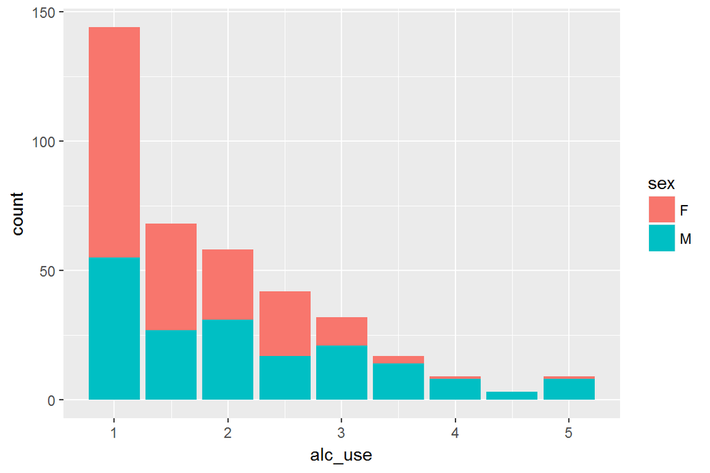

```r
g7 <- ggplot(data = url, aes(x = alc_use, fill = sex))
g7 + geom_bar()
```

The alc use variable is clearly distributed mostly on the left side, which means that the alcohol consumption is smaller. The most common value in this variable is 1. It is very interesting that the proportion of women are larger in the values 1 and 1.5, and when the value is 3 or larger, men has the higher proportion. In other words I conclude that men consume more alcohol than women.

#### Tables and visuals of the variable high_use

```r
table(url$high_use)
```

```
##
## FALSE  TRUE
##   270   112
```

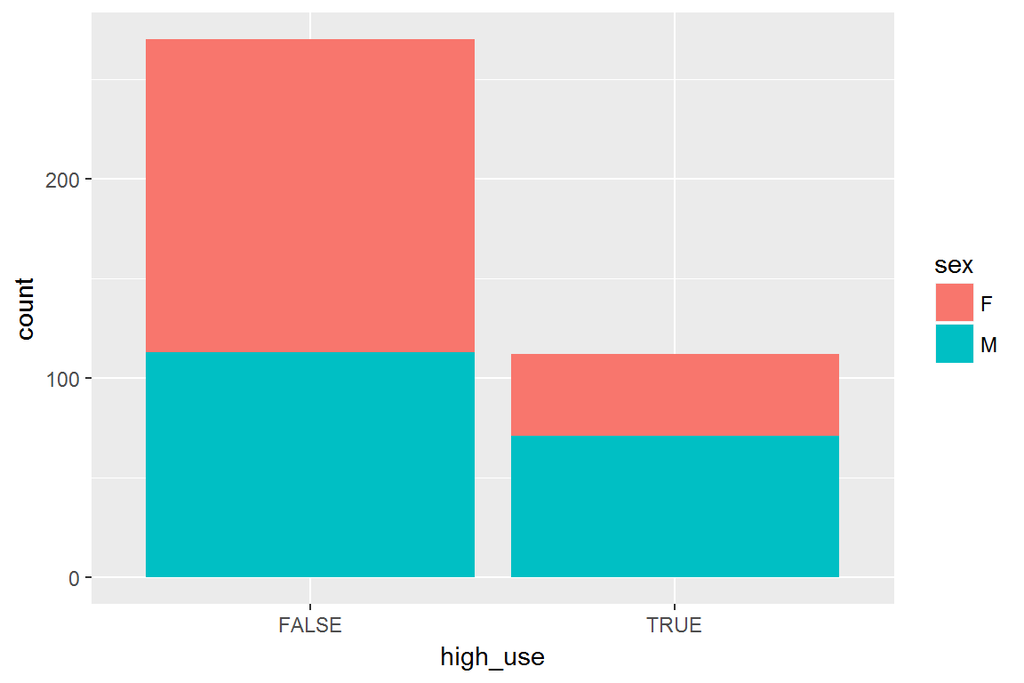

```r
g8 <- ggplot(data = url, aes(x = high_use, fill = sex))
g8 + geom_bar()
```

The distribution supports my previous assumptions regarding the gender difference in alcohol consumption. Here we can see that in the FALSE group (=<2), has a majority of women. On the other hand, the TRUE group has a majority of men. This was not an unexpeced result, because alc_use and high_use use the same variables and data.

## 4 interesting variables

The first variable is ‘failures’, this variable measures how many times the individual has failed from a scale from 0-3 and more than 4. I think high use of alcohol could lead to a higher rate of failure in school. This bases on the hypothesis that alcohol consumption could lead to less success in school.

The third variable is ‘famrel’ that measures the quality of the relationship with the family. This variable ranges from 1-5, where 1 is very bad, and 5 is excellent.

The forth variable ‘goout’ that measures the respondents opinion on how often he/she goes out with friends on a scale from 1-5, where 1 equals very low, 5 equals very high.

### Tables and visuals of the variable failures

```r
table(url$failures)
```

```
##
##   0   1   2   3
## 316  38  11  17
```

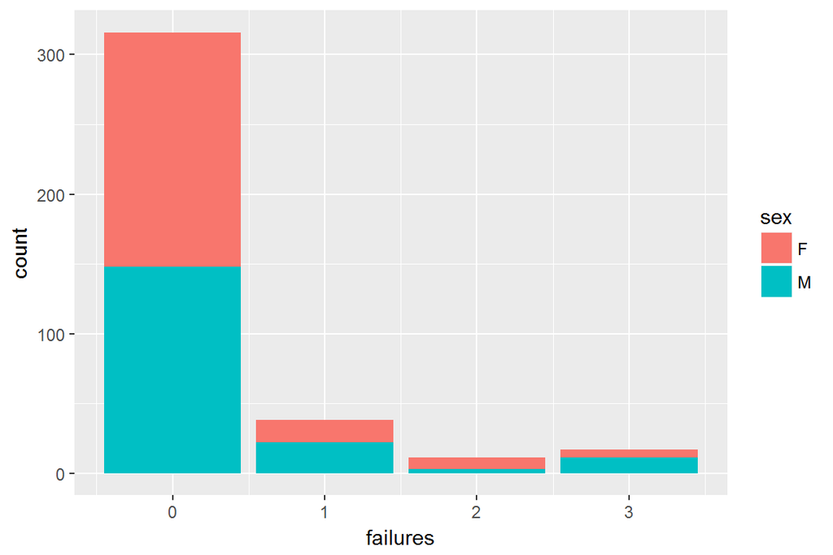

```r
g3 <- ggplot(data = url, aes(x = failures, fill = sex))
g3 + geom_bar()
```

From this table we can see how many failures in tests individuals has made, and also explore the difference between the genders.

In the first value 0, there is no significant difference between the genders, and we can also conclude that this is the most common value in this variable (316). But there are slight differences between the values 1,2 and 3, but I am unsurtain if they are significant or not.

*hypothesis* My hypothesis regarding the amount of faliures and alcohol use, is that the higher the failure rate is ,the higher is the alcohol consumption. In other words, I think there will be a correlation between high use of alcohol and high amount of failures. I base my hypothesis on the fact that large amounts of alcohol could have a negative effect on school grades/failures.

### Tables and visuals of the variable absences

```r
table(url$absences)
```

```
##
##   0   1   2   3   4   5   6   7   8   9  10  11  12  13  14  15  16  17
## 116   3  67   6  51   4  30   8  21   3  17   2  10   3  11   3   6   1
##  18  19  20  21  22  23  24  25  26  28  30  54  56  75
##   4   1   2   1   3   1   1   1   1   1   1   1   1   1
```

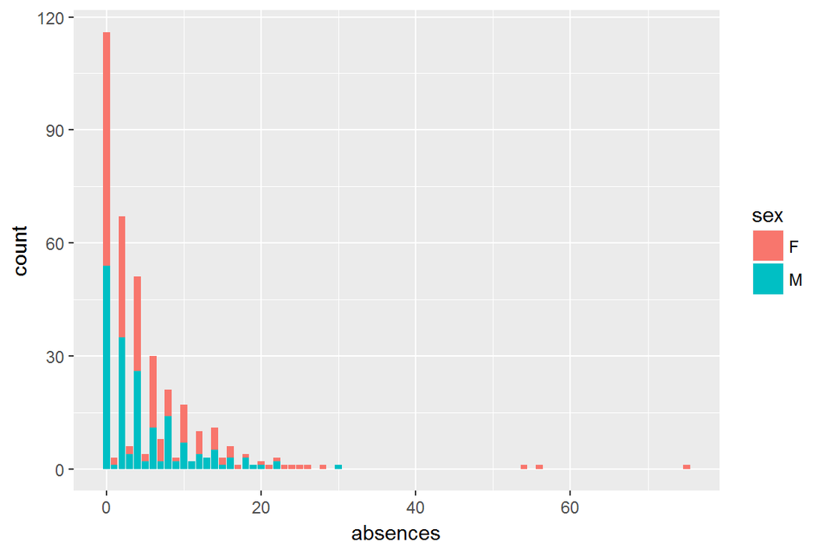

```r
g4 <- ggplot(data = url, aes(x = absences, fill = sex))
g4 + geom_bar()
```

The distribution of absences are slightly odd, but I assume that this depends on 2h lectures. The distribution (beginning from the left) every other value is high and low. If we look at the table frame from this variable, we can conclude the same thing. From this distribution it seems that women tend to be more absent from school in comparison to men. The extreme values 54, 56 and 75 are also absences of women.

*hypothesis* The hypotheis regarding the variable absences, is that the more frequantley an individual is absent from school, the more alcohol this individual uses. The hypothesis is not based upon theoretical facts, only on subjective opinions. Some of the individuals might be absent due to excessive use of alcohol.

### Tables and visuals of the variable famrel

```r
table(url$famrel)
```

```
##
##   1   2   3   4   5
##   9  18  66 183 106
```

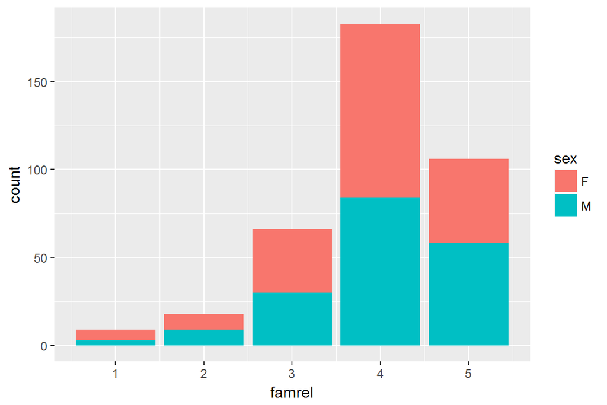

```r
g5 <- ggplot(data = url, aes(x = famrel, fill = sex))
g5 + geom_bar()
```

The variable that measure the family relationship from a scale from 1-5(very bad - excellent), we can see that the distribution is on the most part between 3 and 5. We can conclude that most of the respondents have between a neutral and an excellent relationship with their families.

*hypothesis* The hypothesis regarding he variable that measures the family relationship and alcohol consumption, is that hte better the relationship with the family (3<) the less the individuals consume alcohol, or is a high user of alcohol. My hypotheis is based upon the idea, that high use of alcohol could be a cause of bad relations to people that are important to the respondents. So to conclude, my hypothesis is that high values on famrel will correlate to low values of alcohol consumption.

### Tables and visuals of the variable goout

```r
table(url$goout)
```

```
##
##   1   2   3   4   5
##  24  99 123  82  54
```

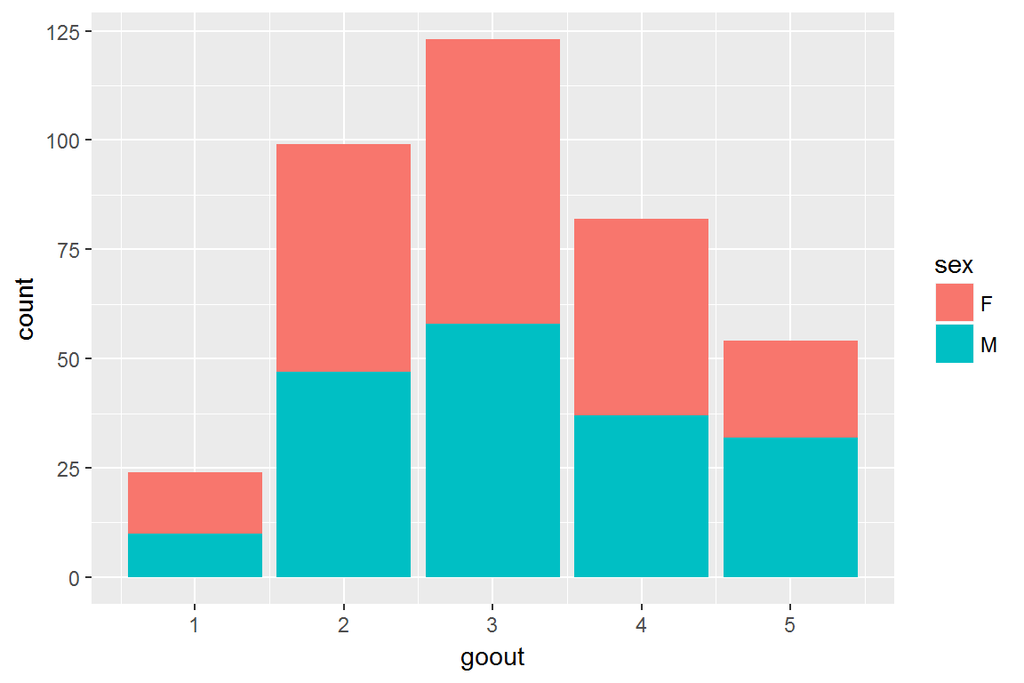

```r
g6 <- ggplot(data = url, aes(x = goout, fill = sex))
g6 + geom_bar()
```

The variable goout measures going out with friends, on a scale from very low(1) to very high(5). Most of the distribution is between the values 2-4, and only a few find themselves spenfinf very low amount of time going out with friends. There is neither a very big difference between the genders.

*hypothesis* The hypothesis to this variable that measures going out with friends and alcohol consumption, is that a high value on the goout could correlate with higher use of alcohol. This hypothesis is based upon my opinion that in group settings it is easier to consume alcohol, in comparison not going out with friend and drinking alcohol alone.

## Exploring the relationships between the variables

### High_use vs absences

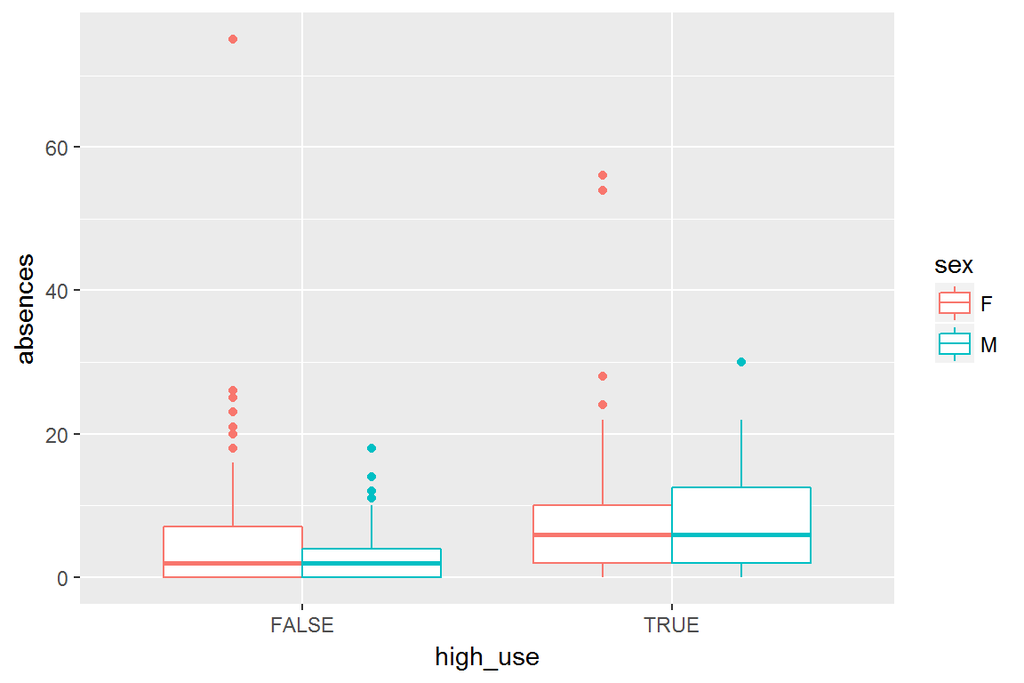

```r
g41 <- ggplot(url, aes(x = high_use, y = absences, col = sex))
g41 + geom_boxplot() + ylab("absences")
```

```r
b <- glm(high_use ~ absences, data = url)
summary(b)
```

```
##
## Call:
## glm(formula = high_use ~ absences, data = url)
##
## Deviance Residuals:
##     Min       1Q   Median       3Q      Max
## -1.2218  -0.2756  -0.2223   0.5645   0.7777
##
## Coefficients:
##             Estimate Std. Error t value Pr(>|t|)
## (Intercept) 0.222303   0.027769   8.006 1.46e-14 ***
## absences    0.013327   0.002989   4.458 1.09e-05 ***
## ---
## Signif. codes:  0 '***' 0.001 '**' 0.01 '*' 0.05 '.' 0.1 ' ' 1
##
## (Dispersion parameter for gaussian family taken to be 0.1979679)
##
##     Null deviance: 79.162  on 381  degrees of freedom
## Residual deviance: 75.228  on 380  degrees of freedom
## AIC: 469.36
##
## Number of Fisher Scoring iterations: 2
```

Here we can explore the individuals that has a high use of alcohol and the once whom not have a high use of alcohol. We can see that the variable is statistically significant (0,000). We can also see that for every absence the intercept increases by 0,013.

We can see a slight difference between the women with high and low alcohol consumption in the difference in absences. But the biggest difference lies in the diffrence between absence with high and low use of alcohol between men. In the low use (FALSE) half of the men are distributed between 0 and less than 5 absences on average. On the other hand, in the high use(TRUE) we can see that half of this group has half of their distributions between 3 and 13 absences on average.

*hypothesis* The hypothesis that the higher amount of absences the higher is the alcohol consumption. So in this distribution we can witness a slight difference between the group of low alcohol use (left side) and the group with high alcohol use (right side). From these boxplots we can see that high useers of alcohol actually has more absences in school. In other words, the hypothesis was confirmed. But I though there would have been a stronger relationship between the two variables.

### high_use vs failures

```r
high_use <-url$high_use
alc_use <-url$alc_use
```

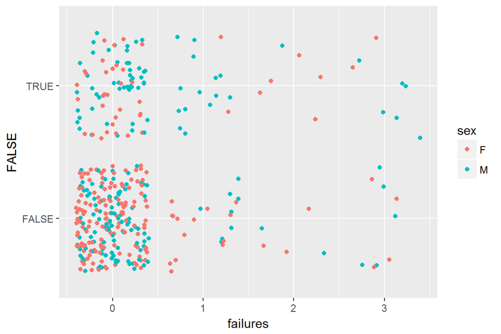

```r
g31 <- ggplot(data = url, aes(x = failures, y = high_use, col = sex))
g31 + geom_jitter() + ylab(high_use)
```

```r
m <- glm(high_use ~ failures, data = url)
summary(m)
```

```
##
## Call:
## glm(formula = high_use ~ failures, data = url)
##
## Deviance Residuals:
##     Min       1Q   Median       3Q      Max
## -0.5532  -0.2653  -0.2653   0.6387   0.7347
##
## Coefficients:
##             Estimate Std. Error t value Pr(>|t|)
## (Intercept)  0.26531    0.02484   10.68  < 2e-16 ***
## failures     0.09596    0.03167    3.03  0.00262 **
## ---
## Signif. codes:  0 '***' 0.001 '**' 0.01 '*' 0.05 '.' 0.1 ' ' 1
##
## (Dispersion parameter for gaussian family taken to be 0.2034088)
##
##     Null deviance: 79.162  on 381  degrees of freedom
## Residual deviance: 77.295  on 380  degrees of freedom
## AIC: 479.71
##
## Number of Fisher Scoring iterations: 2
```

```r
coef(m)
```

```
## (Intercept)    failures
##  0.26531008  0.09595992
```

From this output, we can find that for every more failure, the alcohol consumption will increace by 0,096.

*hypothesis* My hypothesis regarding the amount of failures would signifiantly correlate with high alcohol use, is not as clear as I had hoped for. According to the summary of the regression model it is significant, but how many times you fail a class has a very small inpact on the high alcohol use.

### High_use vs. famrel

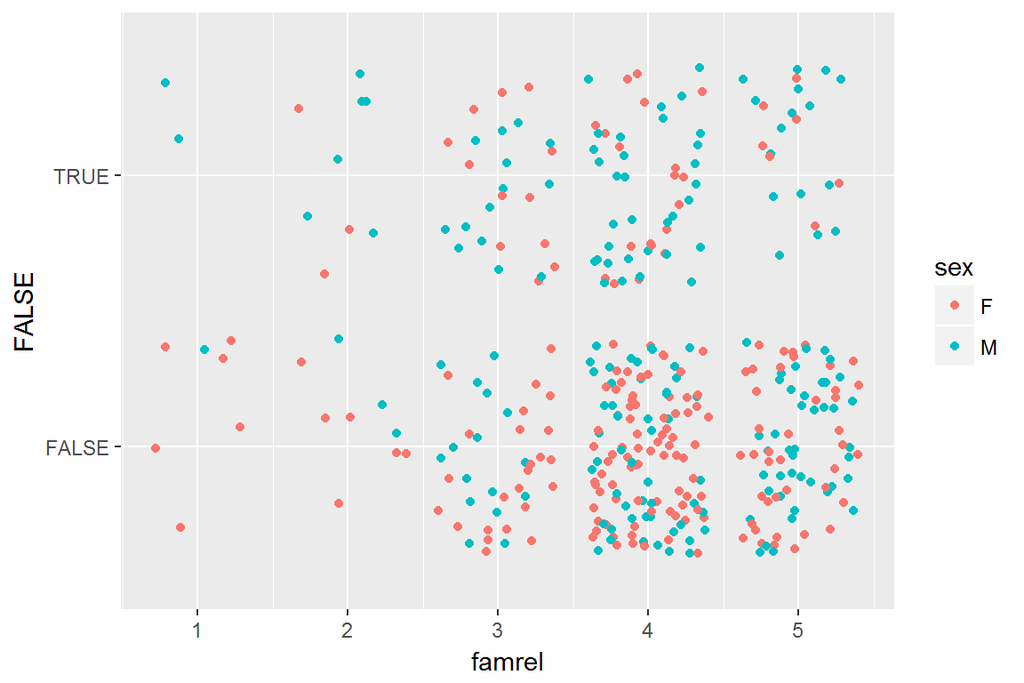

```r
g51 <- ggplot(data = url, aes(x = famrel, y = high_use, col = sex))
g51 + geom_jitter() + ylab(high_use)
```

```r
n <- glm(high_use ~ famrel, data = url)
summary(n)
```

```
##
## Call:
## glm(formula = high_use ~ famrel, data = url)
##
## Deviance Residuals:
##     Min       1Q   Median       3Q      Max
## -0.4772  -0.2894  -0.2268   0.6480   0.7732
##
## Coefficients:
##             Estimate Std. Error t value Pr(>|t|)
## (Intercept)  0.53980    0.10183   5.301 1.96e-07 ***
## famrel      -0.06259    0.02517  -2.487   0.0133 *
## ---
## Signif. codes:  0 '***' 0.001 '**' 0.01 '*' 0.05 '.' 0.1 ' ' 1
##
## (Dispersion parameter for gaussian family taken to be 0.2049851)
##
##     Null deviance: 79.162  on 381  degrees of freedom
## Residual deviance: 77.894  on 380  degrees of freedom
## AIC: 482.66
##
## Number of Fisher Scoring iterations: 2
```

```r
coef(n)
```

```
## (Intercept)      famrel
##  0.53980311 -0.06259454
```

From the output we can find that for every one step on the famrel scale, the alcohol use reduces by 0,06. This is also what my hypothesis claimed.

*hypothesis* Again my hypothesis in confirmed, but I am still not very pleased. This variable (famrel) is statistically significant, but the difference it makes is very small. I thought there would have been a bigger impact on alcohol use and bad family relationships.

### High_use vs goout

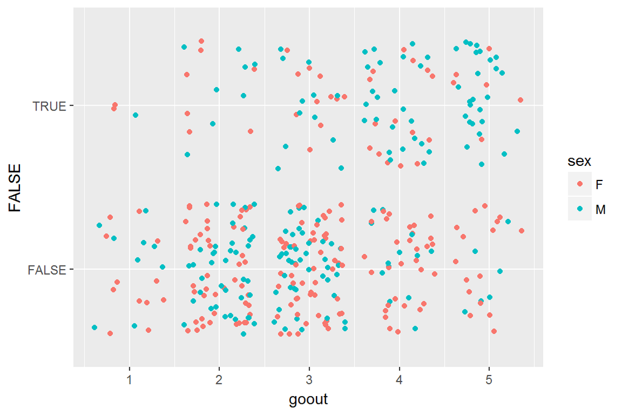

```r
g61 <- ggplot(data = url, aes(x = goout, y = high_use, col = sex))
g61 + geom_jitter() + ylab(high_use)
```

```r
e <- glm(high_use ~ goout, data = url)
summary(e)
```

```
##
## Call:
## glm(formula = high_use ~ goout, data = url)
##
## Deviance Residuals:
##     Min       1Q   Median       3Q      Max
## -0.5615  -0.2772  -0.1350   0.4385   1.0071
##
## Coefficients:
##             Estimate Std. Error t value Pr(>|t|)
## (Intercept) -0.14926    0.06400  -2.332   0.0202 *
## goout        0.14215    0.01933   7.355 1.19e-12 ***
## ---
## Signif. codes:  0 '***' 0.001 '**' 0.01 '*' 0.05 '.' 0.1 ' ' 1
##
## (Dispersion parameter for gaussian family taken to be 0.1823632)
##
##     Null deviance: 79.162  on 381  degrees of freedom
## Residual deviance: 69.298  on 380  degrees of freedom
## AIC: 437.99
##
## Number of Fisher Scoring iterations: 2
```

*hypothesis* My hypothesis was once again confirmed, and there is a statistically significant relationship between the two variables. The impact of going out with friend is bigger than all the other explanatory variables, so I am pleased with the results. This confirms that going out more could increace the alcohol consumption.

## Multiple logistic regression

But, just because every variable is individually significant with the high alcohol use variable, doens’t mean it is statistically significant if we test them all together at once.

```r
f <- glm(high_use ~ failures + absences + goout + famrel, data = url, family = "binomial")
```

```r
summary(f)
```

```
##
## Call:
## glm(formula = high_use ~ failures + absences + goout + famrel,
##     family = "binomial", data = url)
##
## Deviance Residuals:
##     Min       1Q   Median       3Q      Max
## -1.8167  -0.7339  -0.5133   0.8438   2.5091
##
## Coefficients:
##             Estimate Std. Error z value Pr(>|z|)
## (Intercept) -2.31558    0.62610  -3.698 0.000217 ***
## failures     0.28745    0.16289   1.765 0.077619 .
## absences     0.05678    0.01609   3.529 0.000417 ***
## goout        0.76620    0.12164   6.299 2.99e-10 ***
## famrel      -0.38865    0.13585  -2.861 0.004225 **
## ---
## Signif. codes:  0 '***' 0.001 '**' 0.01 '*' 0.05 '.' 0.1 ' ' 1
##
## (Dispersion parameter for binomial family taken to be 1)
##
##     Null deviance: 462.21  on 381  degrees of freedom
## Residual deviance: 385.20  on 377  degrees of freedom
## AIC: 395.2
##
## Number of Fisher Scoring iterations: 4
```

Failures is not any longer statistically significant with the target variable high_use, so I shall remove the failure variable from the logistic regression. This means that I shall run the logistic regression again, but without the failures variable.

```r
f2 <- glm(high_use ~ + absences + goout + famrel, data = url, family = "binomial")
```

```r
summary(f2)
```

```
##
## Call:
## glm(formula = high_use ~ +absences + goout + famrel, family = "binomial",
##     data = url)
##
## Deviance Residuals:
##     Min       1Q   Median       3Q      Max
## -1.8808  -0.7599  -0.5297   0.8415   2.5030
##
## Coefficients:
##             Estimate Std. Error z value Pr(>|z|)
## (Intercept) -2.28530    0.62653  -3.648 0.000265 ***
## absences     0.05691    0.01614   3.526 0.000422 ***
## goout        0.79744    0.12153   6.562 5.33e-11 ***
## famrel      -0.40001    0.13505  -2.962 0.003057 **
## ---
## Signif. codes:  0 '***' 0.001 '**' 0.01 '*' 0.05 '.' 0.1 ' ' 1
##
## (Dispersion parameter for binomial family taken to be 1)
##
##     Null deviance: 462.21  on 381  degrees of freedom
## Residual deviance: 388.31  on 378  degrees of freedom
## AIC: 396.31
##
## Number of Fisher Scoring iterations: 4
```

Now all the explanatory variables are statistically significant, so we can start to explore the odds ratios and the confidence intervalls for this model.

#### Odds ratios

```r
OR <- coef(f2) %>% exp()
```

#### Confidence intervalls

```r
CI <- confint(f2) %>% exp()
```

#### The odds ratios with their confidence intervalls

```r
cbind(OR, CI)
```

```
##                    OR      2.5 %    97.5 %
## (Intercept) 0.1017440 0.02880525 0.3385210
## absences    1.0585652 1.02737360 1.0957362
## goout       2.2198616 1.76075036 2.8384958
## famrel      0.6703131 0.51265117 0.8721354
```

To interpet these confidence intervalls and odds ratios:

The OR (odds ratio) explains how likley it is for a specific variable to appear. The odds ratio ranges from >0 to infinity. To exemplify this statement, we can look at the goout variable. The goout variables odds ratio is 2,22, which means, that it is a little over 2 times more likley to happened.

## Tabulation, binary prediction

Here I shall present the statistically significant explanatory variables and how to make binary predictions.

The first step I am making is creating a new variable, that consists of the function glm, in other words is to fit the logistic regression with the target variable (high_use) and explanatory variables (absences, goout, famrel).

```r
f2 <- glm(high_use ~ absences + goout + famrel, data = url, family = "binomial")
```

##### predicting

Here we use the predict function on the new variable (f2), and these values shall become a new value called probabilities.

```r
probabilities <- predict(f2, type = "response")
```

The next step that we are making, is adding the new predicted propabilities (f2) to the data we are using (url).

```r
url <- mutate(url, probability = probabilities)
```

Now we are using the new propabilities, and we shall predict the values of our target variable high_use.

```r
url <- mutate(url, prediction = probability > 0.5)
```

In this phase we want to present a table of all the target variables and the predictions of the target variables and look how they are distributed.

```r
table(high_use = url$high_use, prediction = url$prediction)
```

```
##         prediction
## high_use FALSE TRUE
##    FALSE   249   21
##    TRUE     67   45
```

Here we can se on the horizontal line we hade the high_use distribution between the distribution of FALSE and TRUE. Anf on the vertical line we can se how the predictions of high_use are distributed between FALSE and TRUE.

Next I wanted to make this plot to visualize the distribution of the probability and high_use, and defining the colors as predictions. The red color in the predictions means FALSE, and the blue color means TRUE.

```r
t <- ggplot(url, aes(x = probability, y = high_use, col = prediction))
```

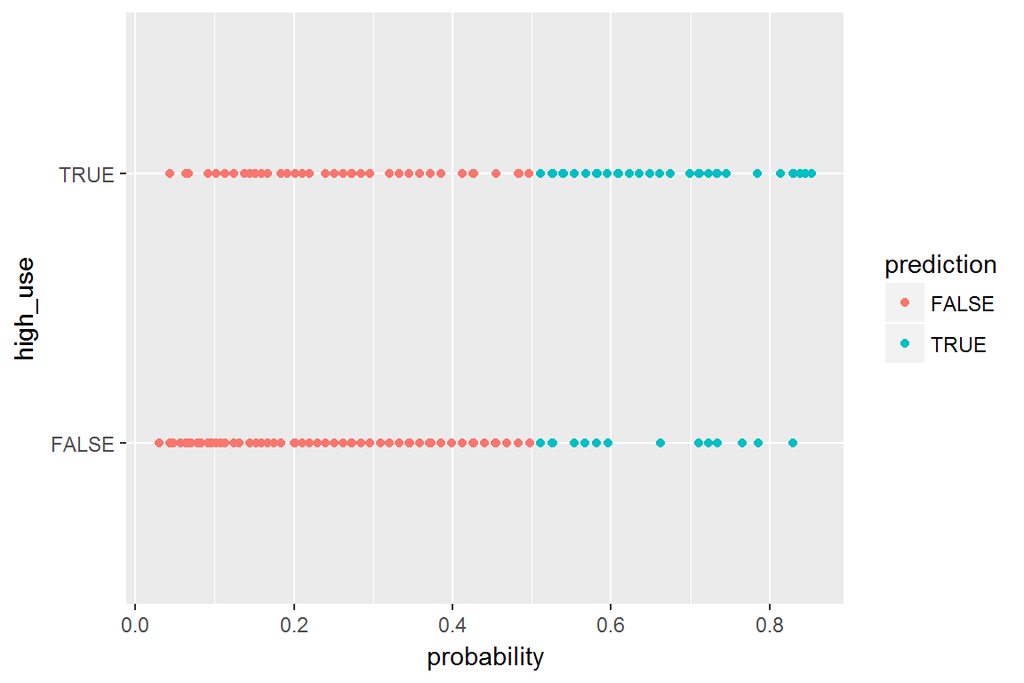

```r
t + geom_point()
```

Now when we have vizuals of the distributions of the probabilities and high_use, I still want to create a new table, that compares the target variables and probabilities in procent format.

```r
table(high_use = url$high_use, prediction = url$prediction) %>% prop.table %>% addmargins
```

```
##         prediction
## high_use      FALSE       TRUE        Sum
##    FALSE 0.65183246 0.05497382 0.70680628
##    TRUE  0.17539267 0.11780105 0.29319372
##    Sum   0.82722513 0.17277487 1.00000000
```

#### Inaccuracy

*loss_func <- function(class, prob) {* *n_wrong <- url(class - prob) > 0.5* *mean(n_wrong)* *}*

After this step I need to use this new variable loss_func, and use it to measure the mean value of the wrong preditions. This is done by using the loss function to classify the data into high_use, and use the probabilities of the url variable propability.

*loss_func(class, prob)*

This code does only give me error, and it seems the fault is found in the definign of the loss_func variable, but I don’t know how to fix it. So sadly I can’t run the two last codes due to not being able to find the error in the loss_func code.

# Chapter 4: Clustering and classification

## 2. Load the Boston data

Now when I have accessed the Boston data, I shall present the structure and dimensions of the data frame.

```r
dim(Boston)
```

```
## [1] 506  14
```

```r
str(Boston)
```

```
## 'data.frame':    506 obs. of  14 variables:
##  $ crim   : num  0.00632 0.02731 0.02729 0.03237 0.06905 ...
##  $ zn     : num  18 0 0 0 0 0 12.5 12.5 12.5 12.5 ...
##  $ indus  : num  2.31 7.07 7.07 2.18 2.18 2.18 7.87 7.87 7.87 7.87 ...
##  $ chas   : int  0 0 0 0 0 0 0 0 0 0 ...
##  $ nox    : num  0.538 0.469 0.469 0.458 0.458 0.458 0.524 0.524 0.524 0.524 ...
##  $ rm     : num  6.58 6.42 7.18 7 7.15 ...
##  $ age    : num  65.2 78.9 61.1 45.8 54.2 58.7 66.6 96.1 100 85.9 ...
##  $ dis    : num  4.09 4.97 4.97 6.06 6.06 ...
##  $ rad    : int  1 2 2 3 3 3 5 5 5 5 ...
##  $ tax    : num  296 242 242 222 222 222 311 311 311 311 ...
##  $ ptratio: num  15.3 17.8 17.8 18.7 18.7 18.7 15.2 15.2 15.2 15.2 ...
##  $ black  : num  397 397 393 395 397 ...
##  $ lstat  : num  4.98 9.14 4.03 2.94 5.33 ...
##  $ medv   : num  24 21.6 34.7 33.4 36.2 28.7 22.9 27.1 16.5 18.9 ...
```

Here we can explore and find that the Boston data has 14 variables and 506 observations. The first variable ‘crim’ is measured by per capita crime rate by town. The ‘zn’ variable measures the proportion of residential land zoned for lots over 25,000 sq.ft. The ‘black’ variable measures the proportions of dark skinned population in a specific town. The ‘lstat’ is a measurement of how many people there are in the lower status population in procent. The value ’ptratio’is the ratio between the teacher and the students in a specific town.

This ‘Boston’ data frame tries to gather data regarding crime rates, schools, taxes and the ratio of the black community.

## 3. Graphical overview and summaries

### Summary of the Boston data frame

```r
summary(Boston)
```

```
##       crim                zn             indus            chas
##  Min.   : 0.00632   Min.   :  0.00   Min.   : 0.46   Min.   :0.00000
##  1st Qu.: 0.08204   1st Qu.:  0.00   1st Qu.: 5.19   1st Qu.:0.00000
##  Median : 0.25651   Median :  0.00   Median : 9.69   Median :0.00000
##  Mean   : 3.61352   Mean   : 11.36   Mean   :11.14   Mean   :0.06917
##  3rd Qu.: 3.67708   3rd Qu.: 12.50   3rd Qu.:18.10   3rd Qu.:0.00000
##  Max.   :88.97620   Max.   :100.00   Max.   :27.74   Max.   :1.00000
##       nox               rm             age              dis
##  Min.   :0.3850   Min.   :3.561   Min.   :  2.90   Min.   : 1.130
##  1st Qu.:0.4490   1st Qu.:5.886   1st Qu.: 45.02   1st Qu.: 2.100
##  Median :0.5380   Median :6.208   Median : 77.50   Median : 3.207
##  Mean   :0.5547   Mean   :6.285   Mean   : 68.57   Mean   : 3.795
##  3rd Qu.:0.6240   3rd Qu.:6.623   3rd Qu.: 94.08   3rd Qu.: 5.188
##  Max.   :0.8710   Max.   :8.780   Max.   :100.00   Max.   :12.127
##       rad              tax           ptratio          black
##  Min.   : 1.000   Min.   :187.0   Min.   :12.60   Min.   :  0.32
##  1st Qu.: 4.000   1st Qu.:279.0   1st Qu.:17.40   1st Qu.:375.38
##  Median : 5.000   Median :330.0   Median :19.05   Median :391.44
##  Mean   : 9.549   Mean   :408.2   Mean   :18.46   Mean   :356.67
##  3rd Qu.:24.000   3rd Qu.:666.0   3rd Qu.:20.20   3rd Qu.:396.23
##  Max.   :24.000   Max.   :711.0   Max.   :22.00   Max.   :396.90
##      lstat            medv
##  Min.   : 1.73   Min.   : 5.00
##  1st Qu.: 6.95   1st Qu.:17.02
##  Median :11.36   Median :21.20
##  Mean   :12.65   Mean   :22.53
##  3rd Qu.:16.95   3rd Qu.:25.00
##  Max.   :37.97   Max.   :50.00
```

The variables I will be focusing on in this task is the ‘crime’ variable and ‘black’ variable. From the summary command we can find the distribution of per capita crime rate per town, and notice that most of the town don’t have a major crime issue, but there is still the maximum value of 88.97. The variable ‘black’ shows the population of the black colored community in a town. The minimun value is very low (0.32), but it increses rapidly when we explore the first quartile with the number being 375,38. After this the values don’t increase as much, because the maximum value is 396,90.